# HW 1: CONJ 620 W22

Solutions

Due 1/11/22

## Directions

- For self-grading your assignment, please start with the Part 1 .Rmd file that you already uploaded to Sakai, and make your corrections to that.
  - Add to the beginning of each question your reflection / grading of your response in your original submission in purple so that we can easily distinguish your Part 2 grading from your original Part 1 answer.
  - Check out the code in the Rmd file for how I made this text purple using html code (you can’t see it in the html output).
    - Don’t forget to end the purple text with the code right after this sentence.
- Please upload Part 2 of your homework to Sakai. Upload both your .Rmd code file and the knitted .html file.
  - If you do not upload the html file of your knitted Rmd file, 20 (out of 100) points will be deducted from your homework grade. *If there is an error with code in a code chunk that is preventing the file from knitting, then comment out that code and make a note that it’s not running.*
- The questions are numbered 1-22. Please do not use `(@)` in your edits to this file so that the exercise numbering does not change!
- For each question, make sure to include all code and resulting output in the html file to support your answers. Answers to questions do not need be lengthy, but thoughtful and descriptive.
- Please only use techniques covered in the first week to answer these questions. In particular, we have not covered data wrangling yet.
- For the data visualizations, you do not have change the default colors or themes or legends. However, you are of course welcome to do so if you like.

> Tip: It is a good idea to try kitting your document from time to time as you go along! Note that knitting automatically saves your Rmd file and knitting frequently helps you catch your errors more quickly.

## Load packages & data

- Below is code to load the packages we need for this assignment. There is a new package `palmerpenguins` that you will also need to first install (use commented out code).
  - Notice that when loading the `tidyverse` package, that `ggplot2` is one of the packages that gets loaded. Thus, we don’t need to separately load `ggplot2`.
- Note that the R chunk includes `message = FALSE` in the first line. This is so that the messages that appear when loading the packages don’t show up in your knitted html file. The messages will still appear within the R console when running it within RStudio.

```r
library(tidyverse)

# install.packages("palmerpenguins")
library(palmerpenguins)
```

# Penguins data exploration

Explore the `penguins` dataset using the base R commands from Day 1.

1. **How many observations and variables are included in this dataset?**

```r
data(penguins)
dim(penguins)
```

```
## [1] 344   8
```

```r
names(penguins)
```

```
## [1] "species"           "island"            "bill_length_mm"
## [4] "bill_depth_mm"     "flipper_length_mm" "body_mass_g"
## [7] "sex"               "year"
```

There are 8 variables in the penguins dataset, with 344 observations. Since there is no column for a unique identifier, we will assume that each row is an observation for a unique penguin (no repeated measures).

2. **Give a brief description of each variable.** In particular:
   - Based on the variable name (& that the name of the dataset is penguins), what is your best guess as to what the variable represents?
   - What is the variable type? Give both the R variable type and classify the variable as being discrete, continuous, ordinal, or nominal (see Section 1.2.2 (pgs. 15-16) of Vu & Harrington).
   - Give a brief summary of the variable. Pretend you are describing the data to someone who is not familiar with the dataset.

```r
str(penguins)
```

```
## tibble [344 × 8] (S3: tbl_df/tbl/data.frame)
##  $ species          : Factor w/ 3 levels "Adelie","Chinstrap",..: 1 1 1 1 1 1 1 1 1 1 ...
##  $ island           : Factor w/ 3 levels "Biscoe","Dream",..: 3 3 3 3 3 3 3 3 3 3 ...
##  $ bill_length_mm   : num [1:344] 39.1 39.5 40.3 NA 36.7 39.3 38.9 39.2 34.1 42 ...
##  $ bill_depth_mm    : num [1:344] 18.7 17.4 18 NA 19.3 20.6 17.8 19.6 18.1 20.2 ...
##  $ flipper_length_mm: int [1:344] 181 186 195 NA 193 190 181 195 193 190 ...
##  $ body_mass_g      : int [1:344] 3750 3800 3250 NA 3450 3650 3625 4675 3475 4250 ...
##  $ sex              : Factor w/ 2 levels "female","male": 2 1 1 NA 1 2 1 2 NA NA ...
##  $ year             : int [1:344] 2007 2007 2007 2007 2007 2007 2007 2007 2007 2007 ...
```

```r
summary(penguins)
```

```
##       species          island    bill_length_mm  bill_depth_mm
##  Adelie   :152   Biscoe   :168   Min.   :32.10   Min.   :13.10
##  Chinstrap: 68   Dream    :124   1st Qu.:39.23   1st Qu.:15.60
##  Gentoo   :124   Torgersen: 52   Median :44.45   Median :17.30
##                                  Mean   :43.92   Mean   :17.15
##                                  3rd Qu.:48.50   3rd Qu.:18.70
##                                  Max.   :59.60   Max.   :21.50
##                                  NA's   :2       NA's   :2
##  flipper_length_mm  body_mass_g       sex           year
##  Min.   :172.0     Min.   :2700   female:165   Min.   :2007
##  1st Qu.:190.0     1st Qu.:3550   male  :168   1st Qu.:2007
##  Median :197.0     Median :4050   NA's  : 11   Median :2008
##  Mean   :200.9     Mean   :4202                Mean   :2008
##  3rd Qu.:213.0     3rd Qu.:4750                3rd Qu.:2009
##  Max.   :231.0     Max.   :6300                Max.   :2009
##  NA's   :2         NA's   :2
```

# Data viz: what story are the data telling us?

## Scatterplots

### Bill length (y-axis) vs. the bill depth (x-axis)

*Note: we usually say **y-variable vs. x-variable** when referring to a scatterplot, which is opposite of thinking about (x,y).*

3. **Make a scatterplot of the bill length (y-axis) vs. the bill depth (x-axis).**
   - Include some level of transparency of the points.
   - Label the axes with descriptive “nice looking” names that are not the original variable names.
   - Add a title to the plot.

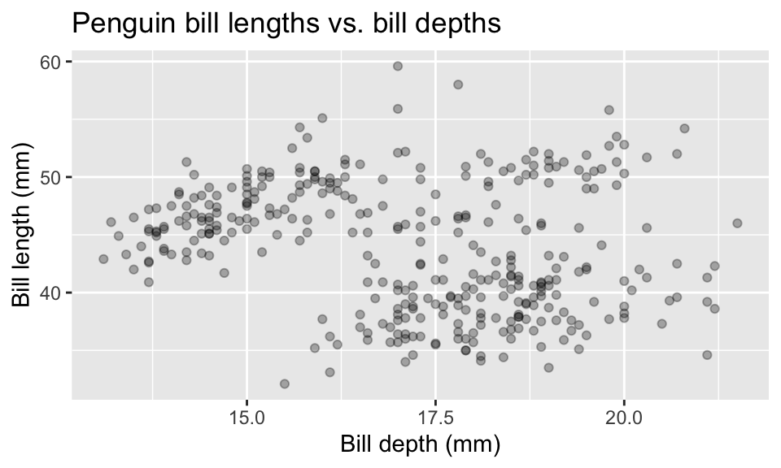

```r
ggplot(data = penguins,
       aes(x = bill_depth_mm,
           y = bill_length_mm)) +
  geom_point(alpha = .3) +
  labs(x = "Bill depth (mm)",
       y = "Bill length (mm)",
       title = "Penguin bill lengths vs. bill depths")
```

4. **Is the linear relationship between these variables best described as being weak, moderate, or strong? Also, is it positive, negative, or neither?**

There is not a strong linear relationship between the variable. It’s a weak negative relationship.  
*Since the relationship is so weak it’s actually difficult to tell if it would be negative or positive. Thus it’s acceptable to say neither or positive instead of negative.*

## Distribution shapes

- We will now explore the distribution shapes of the quantitative variables.
- When describing distribution shapes, consider whether they are symmetric, uniform, skewed left or right, bimodal, multimodal, or some combination there of.

### Flipper lengths

5. **Make a histogram and a density plot for the flipper length.**

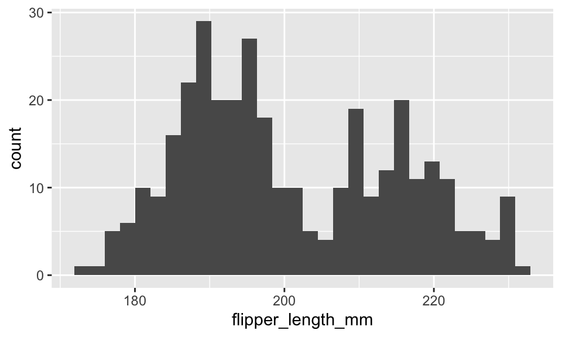

```r
ggplot(data = penguins,
       aes(x = flipper_length_mm)) +
  geom_histogram()
```

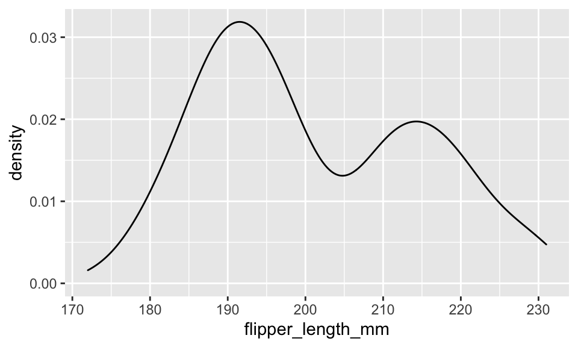

```r
ggplot(data = penguins,
       aes(x = flipper_length_mm)) +
  geom_density()
```

6. **Describe the distribution shape. If the distribution has modes (peaks), what variables do you think might be associated with them?**

The flipper lengths have a bimodal distribution. The two peaks could be due to different species or sex.

### Body mass

7. **Make a histogram and a density plot for the body mass.**

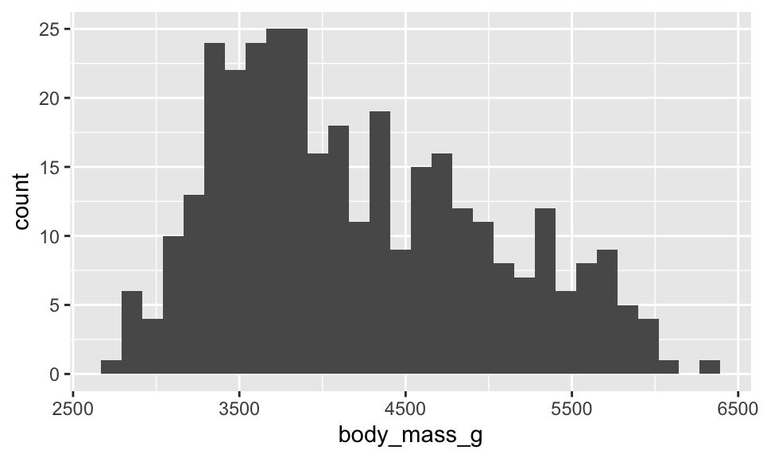

```r
ggplot(data = penguins,
       aes(x = body_mass_g)) +
  geom_histogram()
```

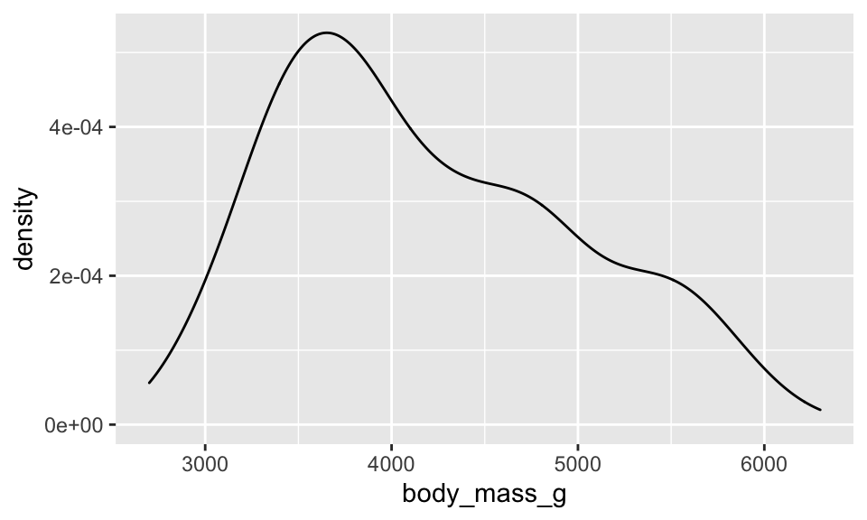

```r
ggplot(data = penguins,
       aes(x = body_mass_g)) +
  geom_density()
```

8. **Describe the distribution shape. If the distribution has modes (peaks), what variables do you think might be associated with them?**

The body masses have a skewed right distribution. There is one main peak.

*You could also point out that there are two more little peaks or humps. Those could associated with different species or sex.*

### Going deeper with flippers

Let’s explore the distributions of flipper lengths by sex and species.

9. **Make a figure with density plots to compare the distribution shapes by sex. What does this plot tell you both about the shapes and comparing the values between groups?**

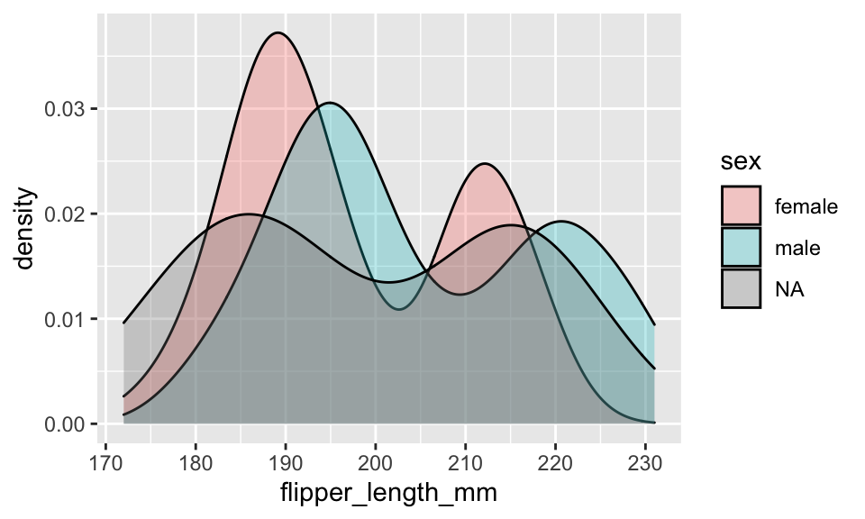

```r
ggplot(data = penguins,
       aes(x = flipper_length_mm,
           fill = sex)) +
  geom_density(alpha = .3)
```

The distributions of flipper lengths are bimodal for both male and female penguins (plus for those penguins with missing values for sex). The two peaks for female penguins are slightly two the left of the peaks for male penguins, indicating that female penguins tend to have slightly shorter flippers. However, the two distinct peaks within each sex tells us that the overall bimodal distribution of flipper lengths is due to some variable other than sex, such as possibly species.

### Color coding bill length (y-axis) vs. the bill depth (x-axis)

10. **Create two new scatterplots, where one color codes the dots by island and the other by species.**

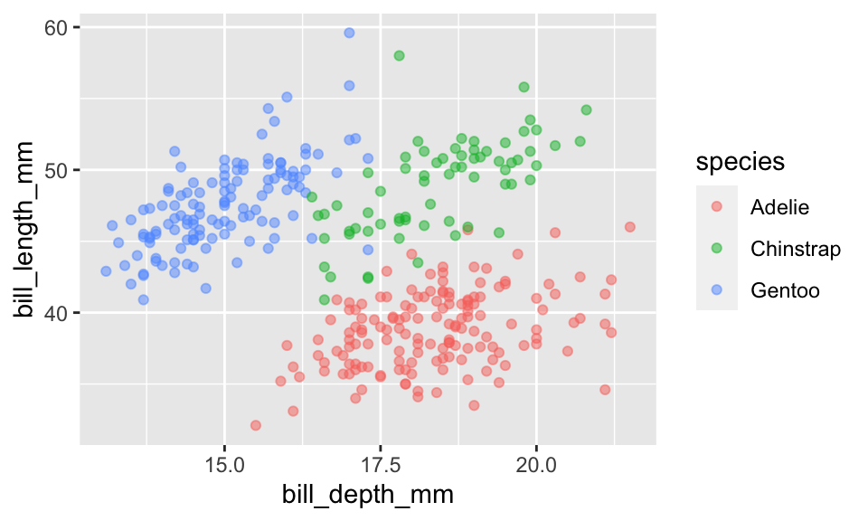

```r
ggplot(data = penguins,
       aes(x = bill_depth_mm,
           y = bill_length_mm,
           color = species)) +
  geom_point(alpha = .5) # you were not required to include alpha
```

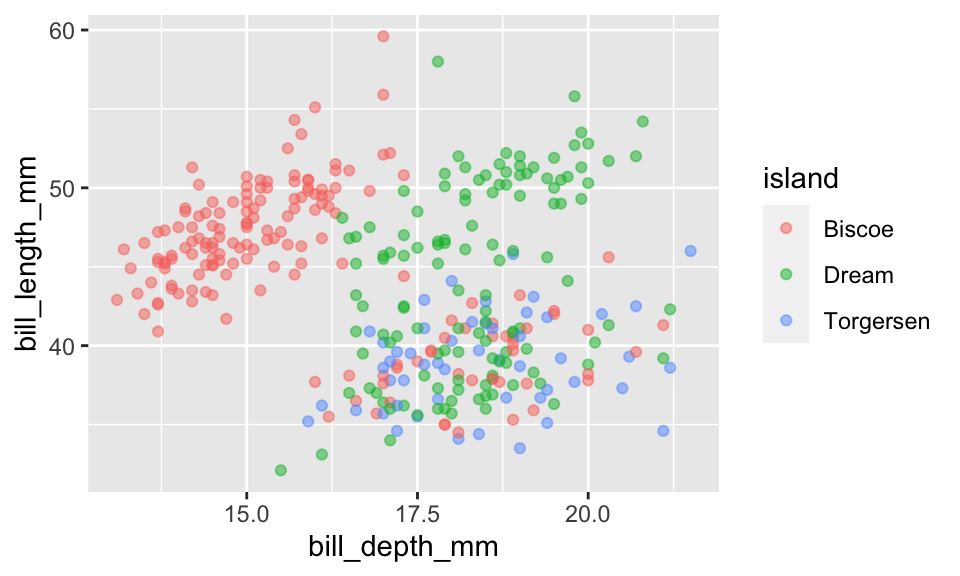

```r
ggplot(data = penguins,
       aes(x = bill_depth_mm,
           y = bill_length_mm,
           color = island)) +
  geom_point(alpha = .5)  # you were not required to include alpha
```

11. **Is the relationship between bill length and depth stronger within islands or within species? Describe how you came to this conclusion. Again, assume that you are talking to someone that doesn’t see the plot.**

The relationship between bill length and depth is stronger within species than within islands. We can see three almost distinct colored clusters of points for the three different species. Gentoo penguins tend to have smaller bill depths and larger bill lengths, Adelie penguins tend to have larger bill depths and smaller bill lengths, and Chinstrap penguins tend to have both larger bill depths and larger bill lengths. For all three species, we see a positive moderate association between bill length and depth.

In contrast, the plot color-coded by island shows much overlap of islands in the cluster of larger bill depths and smaller bill lengths. Thus Biscoe island penguins are split across two clusters, leading to a weak negative relationship between bill length and depth. Dream island penguins are one larger cluster with no clear positive or negative relationship. The Torgersen island penguins have the strongest relationship between bill length and depth amongst the three islands, which is moderate positive.

### Species vs. island?

12. **Take another look at the two color-coded scatterplots. Based on these scatterplots, which species tend to live on which islands?**

Adelie penguins live on all three islands, Chinstrap penguins live on Dream, and Gentoo penguins live on Biscoe.

### Back to flipper lengths…

13. **Make a figure with density plots of the flipper lengths to compare the distribution shapes by species. What does this plot tell you both about the shapes and comparing the values between groups?**

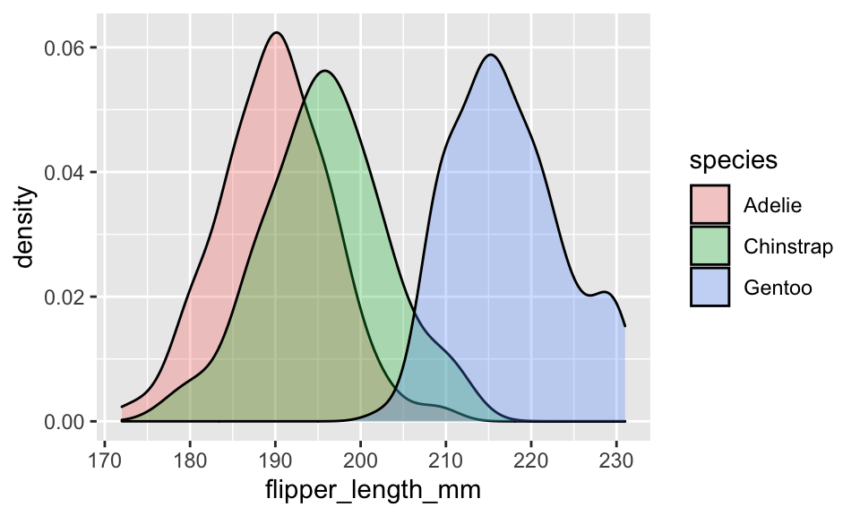

```r
ggplot(data = penguins,
       aes(x = flipper_length_mm,
           fill = species)) +
  geom_density(alpha = .3)
```

Within each of the species, the distribution of flipper lengths is approximately symmetric with one mode. From this plot we can see that Gentoo penguins tend to have the longest flippers with a mode around 215 mm. Adelie and Chinstrap penguins have much overlap in their flipper lengths, with Adelie’s mode at about 190 mm being slightly smaller than Chinstrap’s mode at about 197 mm.

14. **Make a figure with density plots of the flipper lengths to compare the distribution shapes by both sex and species.** *Hint: facet!*

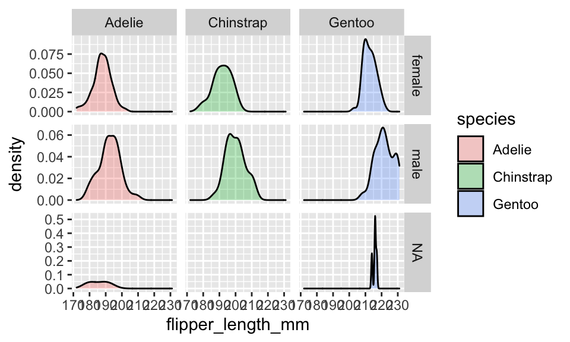

```r
ggplot(data = penguins,
       aes(x = flipper_length_mm,
           fill = species)) +
  geom_density(alpha = .3) +
  facet_grid(rows = vars(sex), cols = vars(species), scales = "free_y")
```

```r
# you didn't have to include the scale = "free_y" part, but it does help to see each of the distribution shapes in greater detail
```

From these plots we see that the distribution of flipper lengths is fairly symmetric and unimodal for each species-sex combination. Male penguins tend to have their modes at slightly larger values that female penguins.

As noted above, Gentoo penguins tend to have the longest flippers with a mode around 215 mm. Adelie and Chinstrap penguins have much overlap in their flipper lengths, with Adelie’s mode at about 190 mm being slightly smaller than Chinstrap’s mode at about 197 mm.

The penguins with missing sex values are from the Adelie and Gentoo species.

## Boxplots

15. **Make a figure of boxplots for flipper lengths for the different sexes.**

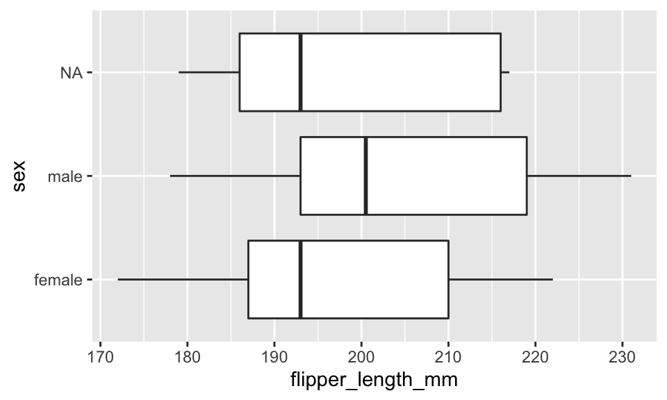

```r
ggplot(data = penguins,
       aes(x = flipper_length_mm,
           y = sex)) +
  geom_boxplot()
```

16. **Build on your previous graph to add faceting by species.**

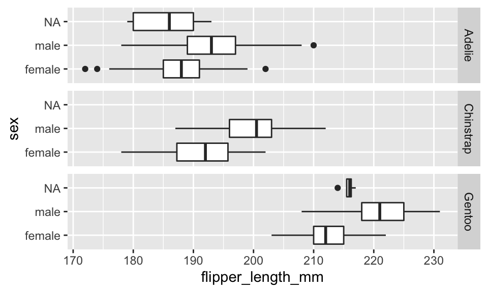

```r
ggplot(data = penguins,
       aes(x = flipper_length_mm,
           y = sex)) +
  geom_boxplot() +
  facet_grid(rows = vars(species))  # or facet_wrap
```

17. **Which species/sex combinations had outliers for flipper length?**

There are outliers for both male and female Adelie flipper lengths.

In addition Gentoo penguins with missing sex have outliers. However, there are very few penguins in this group, and the outlying value is well within the range of Gentoo flipper lengths.

## Bargraphs

Let’s now explore the categorical variables.

18. **Make a bargraph for the species. Which species is the most common? Least common?**

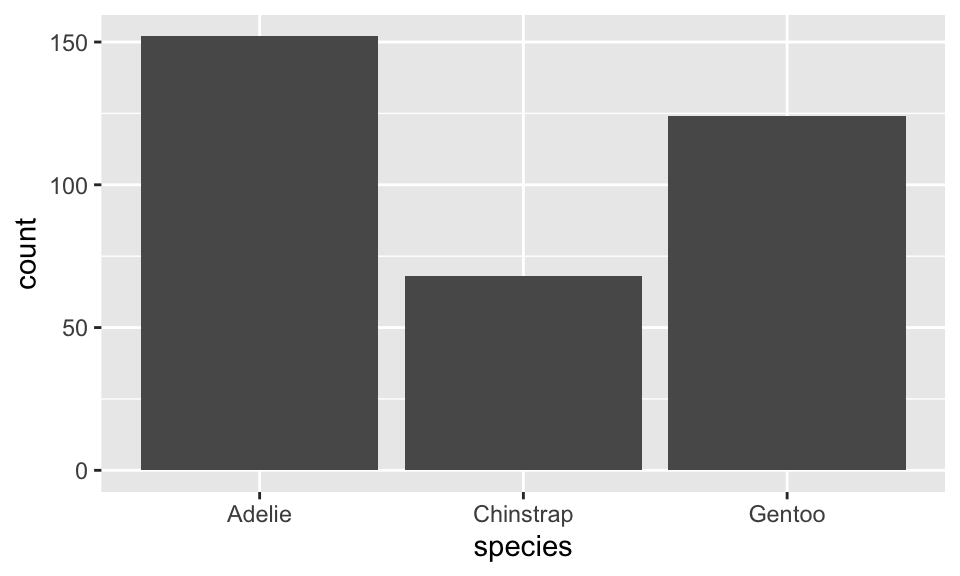

```r
ggplot(data = penguins, aes(x = species)) +
  geom_bar()
```

In the penguins dataset, Adelie penguins were the most common and Chinstrap penguins the least common.

19. **Make a bargraph for the islands. Which island is the most common? Least common?**

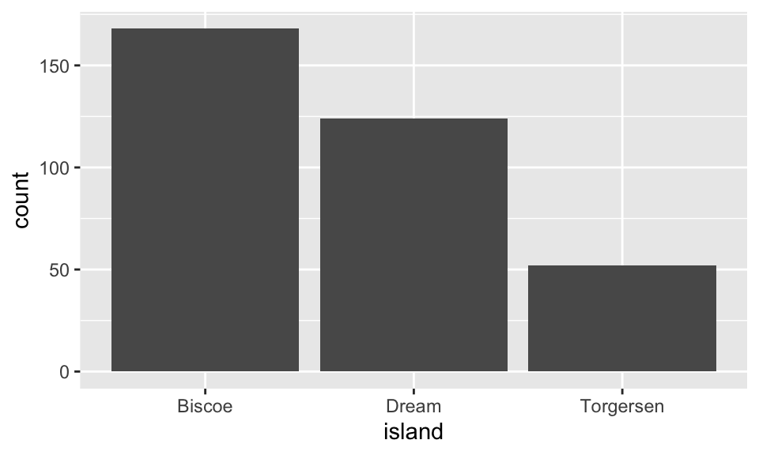

```r
ggplot(data = penguins, aes(x = island)) +
  geom_bar()
```

In the penguins dataset, Biscoe island penguins were the most common and Torgersen island penguins the least common.

### Stacked bargraphs

20. **Make a bargraph for the species stacked by sex. Was sex approximately evenly distributed within each species, or was one sex more common for some or all species?**

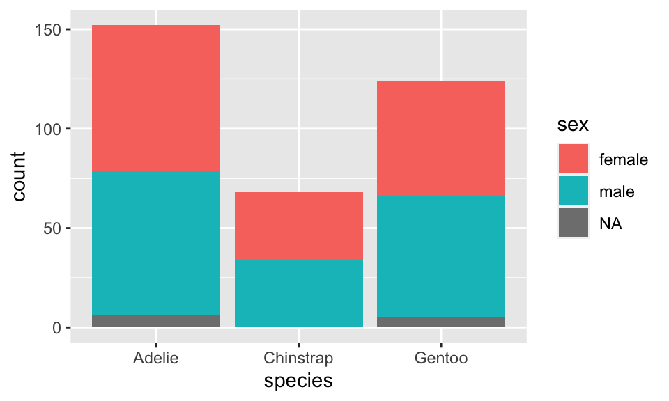

```r
# Either of the 2 bargraphs work for this question.
# The second makes it a little easier to compare the sex distributions by species though.

ggplot(data = penguins, aes(x = species, fill = sex)) +
  geom_bar()
```

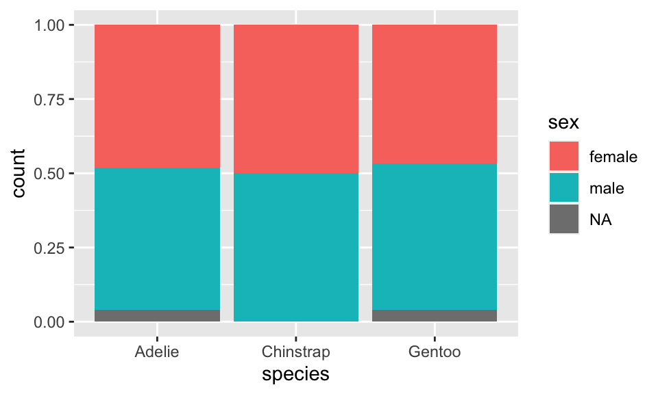

```r
# or
ggplot(data = penguins, aes(x = species, fill = sex)) +
  geom_bar(position = "fill")
```

Sex approximately evenly distributed within each species.

21. **Make a bargraph for the islands stacked by species. What does this plot tell us about the species inhabitants of each of the islands?**

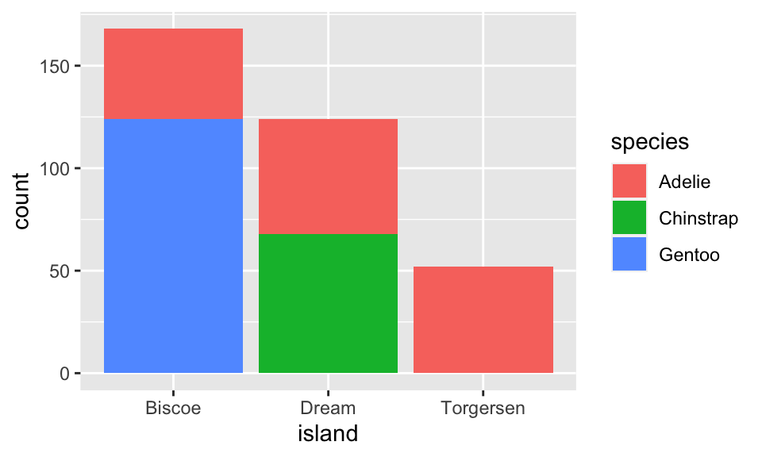

```r
# Either of the 2 bargraphs work for this question.
ggplot(data = penguins, aes(x = island, fill = species)) +
  geom_bar()
```

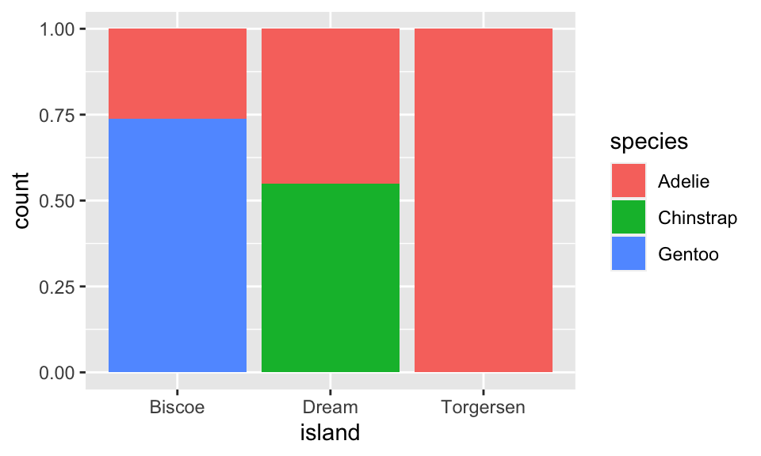

```r
# or
ggplot(data = penguins, aes(x = island, fill = species)) +
  geom_bar(position = "fill")
```

From these barplots we see that Biscoe had the most penguins (over 150), with close to 75% Gentoo and the remaining Adelie. Dream island had about 125 penguins, split approximately evenly between Adelies and Chinstraps. Torgersen had the fewest penguins (about 50), which were all Adelies.

22. **Make various bargrpahs (at least two) to explore the year variable. Based on your figures, what is your guess for how the data were collected over time? I.e. were different species and islands targeted in different years, or were they all targeted over time?**

Below are some sample plots to explore the year variable.

We can see that penguin data was collected for each of the years from 2007 to 2009. There was a slight increase in the number of penguins data was collected on from year to year, but not much (from about 110 penguins in 2007 to 120 in 2009). The number of penguins data was collected on was about the same from year to year on each of the islands and within each of the species, with small fluctuations.

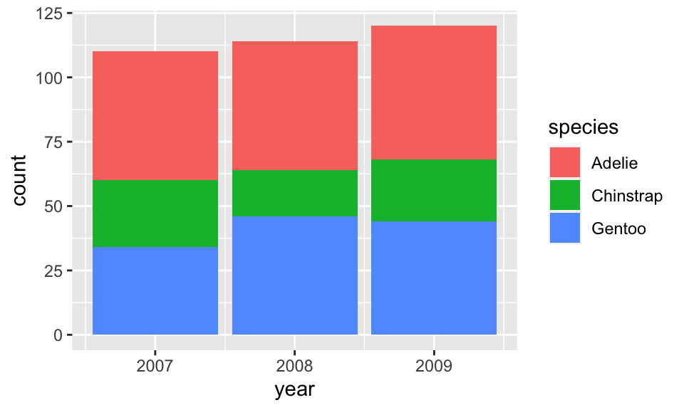

```r
ggplot(data = penguins,
       aes(x = year,
           fill = species)) +
  geom_bar()
```

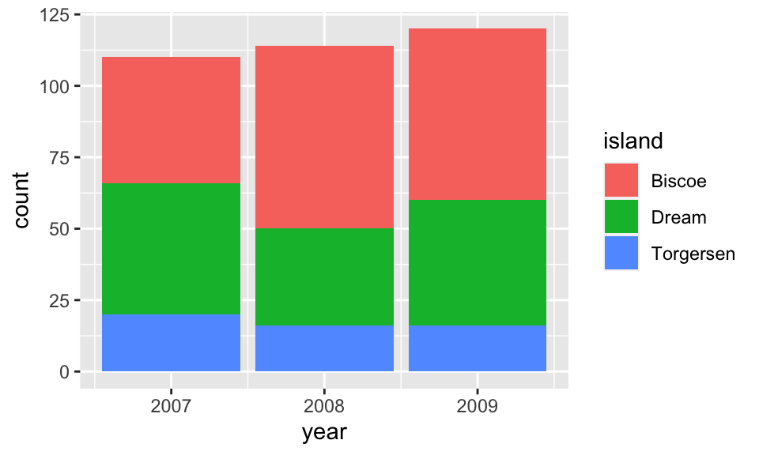

```r
ggplot(data = penguins,
       aes(x = year,
           fill = island)) +
  geom_bar()
```

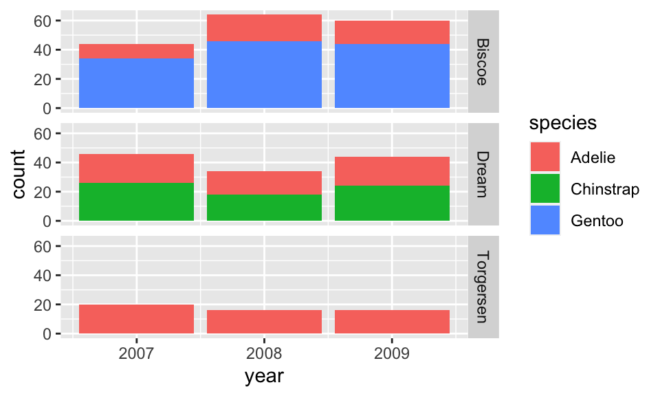

```r
ggplot(data = penguins,
       aes(x = year,
           fill = species)) +
  geom_bar() +
  facet_grid(rows = vars(island))  # or facet_wrap
```